# Data Science Challenge

Gopalakrishnan Kalarikovilagam Subramanian

July 9, 2019

## Introduction

In this data challenge there are 28 variables provided to us. They are:

*Key variables used*:

- duration Duration in minutes
- director_name Name of the Director of the Movie
- director_facebook_likes Number of likes of the Director on his Facebook Page
- actor_1_name Primary actor starring in the movie
- actor_1_facebook_likes Number of likes of the Actor_1 on his/her Facebook Page
- cast_total_facebook_likes Total number of facebook likes of the entire cast of the movie
- movie_facebook_likes Number of Facebook likes in the movie page
- genres Film categorization like Animation, Comedy, Romance, Horror, Sci-Fi
- title_year The year in which the movie is released (1916:2016)
- content_rating Content rating of the movie
- gross Gross earnings of the movie in Dollars
- budget Budget of the movie in Dollars

The following packages are being used for our analysis:

```r
rm(list=ls())
library(readxl)
library(tidyverse)
library(dplyr)
require(gdata)
```

## Data Importing

The following code is used to import the dataset in r after placing them in the working directory.

```r
#import data
Movie = read.xls ("movie_metadata.xls", sheet = 1, header = TRUE)
```

## Data Cleaning

The data set is cleaned to remove duplicates.

```r
# To remove duplicates from the data

Movie <- Movie[!duplicated(Movie[]),]

# To create the  profit column
Movie$profit <- Movie$gross - Movie$budget
```

After data collection it is tidied exploration is done on the data.

## Data Exploration

The summary of the data set is performed. It is overwhelmingly color movies. The shortest film is 7 min and the longest is 511. 50% of the movies are in the 93 min to 118 min range. Actor 1 has on an averge more facebook likes than other crew members.

The lowest amount grossed by a movie is 162 and the highest is more than 760 million. Drama is the highest genre followed by comedy and comedy/drama.

It is found that most of the movies are in english language, followed by french and spanish. USA produces most movies, followed by UK and France. Most of the movies are R rated, followed by PG-13. The lowest budget movie is 218 which seems very small. 75% of the movies in the data set are released after 1999 .The score of the movie range from 1.6 to 9.5. The aspect ratio of the movies range from 1.18 to 16.

```r
summary(Movie)
```

[output not shown]

The plot of top five directors as a function of avaerage profit is done. The directors are filtered on who have more than 5 movies. This gives more reliability on the part of the directors. The top five reliable directors are James Cameroon, Jon Favreau, Steven Spielberg, Christopher Nolan and Jay Roach.

A similar plot is done for first actors and these are the most protitable actors:

Robert Pattison, Bryce Dallas Howard, Steve Carell, Harrison Ford and Jennifer  
Lawrence.

The movies are classified into foir categories : very small if it is less than an hour. Small is it is less than 2 hours, Medium if less than 3 hours and Long if more than 3 hours. A plot of average profit of the movie based on this classification is carried out. It shows that very-short movies are not at all profitable. The most profitable are the medium range movies followed by long range and short movies.

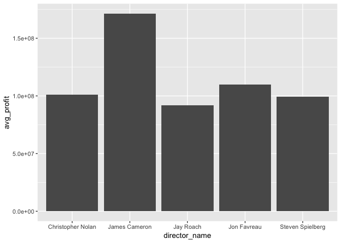

```r
# Top 5 profitable directors
Movie %>% group_by(director_name) %>% summarise(count = n(), avg_profit = mean(profit, na.rm = TRUE)) %>%
  filter(count>5) %>% arrange(-avg_profit) %>% slice(1:5) %>%
  ggplot(aes(x = director_name, y = avg_profit)) + geom_bar(stat="identity")
```

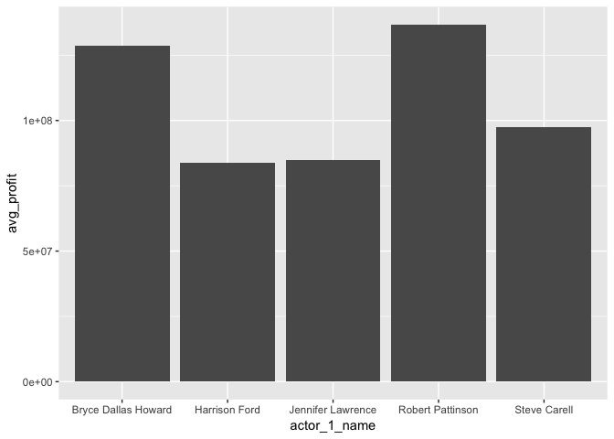

```r
# Top five profitable first actor
Movie %>% group_by(actor_1_name) %>%
  summarise(count = n(), avg_profit = mean(profit, na.rm = TRUE)) %>%
  filter(count>5) %>% arrange(-avg_profit) %>% slice(1:5) %>%
  ggplot(aes(x = actor_1_name, y = avg_profit)) + geom_bar(stat="identity")
```

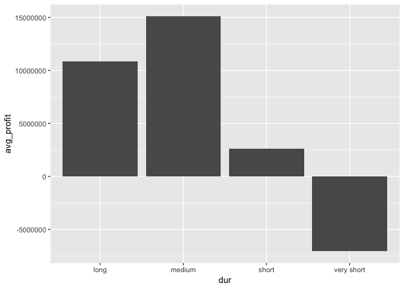

```r
# Classifying movies into different categories and seeing the variation of profit
Movie %>%
  mutate(dur = ifelse(duration<60, 'very short', ifelse(duration<120, 'short', ifelse(duration<180, 'medium', 'long')))) %>%
  group_by(dur) %>% filter(all(!is.na(dur))) %>%
  summarise(avg_profit = mean(profit, na.rm = TRUE)) %>%
  ggplot(aes(x = dur, y = avg_profit)) + geom_bar(stat="identity")
```

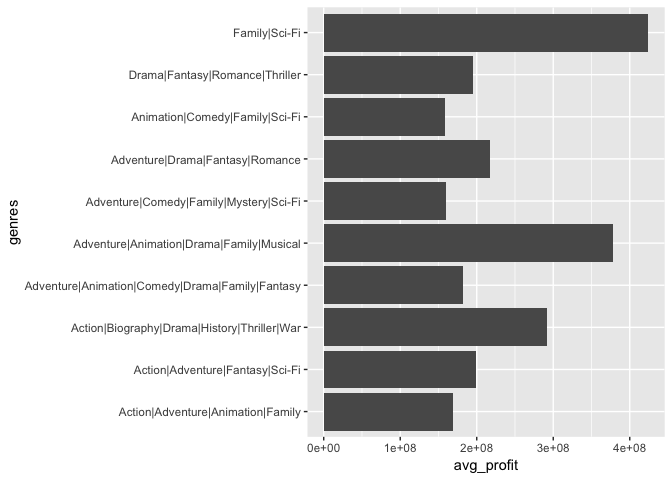

```r
# Classifying movies into different genres and seeing the variation of profit
Movie %>%
  group_by(genres) %>%
  summarise(avg_profit = mean(profit, na.rm = TRUE)) %>% arrange(-avg_profit) %>%
  slice(1:10) %>%
  ggplot(aes(x = genres, y = avg_profit)) + geom_bar(stat="identity") +
  coord_flip()
```

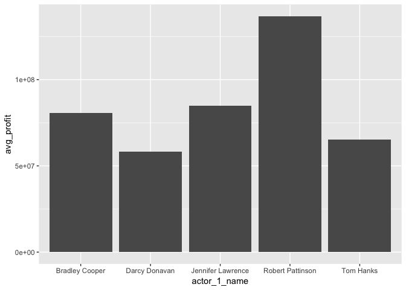

```r
Movie %>%
  group_by(actor_1_name) %>% filter(actor_1_facebook_likes>11000) %>%
  summarise(avg_profit = mean(profit, na.rm = TRUE)) %>% arrange(-avg_profit) %>%
  slice(1:5) %>%
  ggplot(aes(x = actor_1_name, y = avg_profit)) + geom_bar(stat="identity")
```

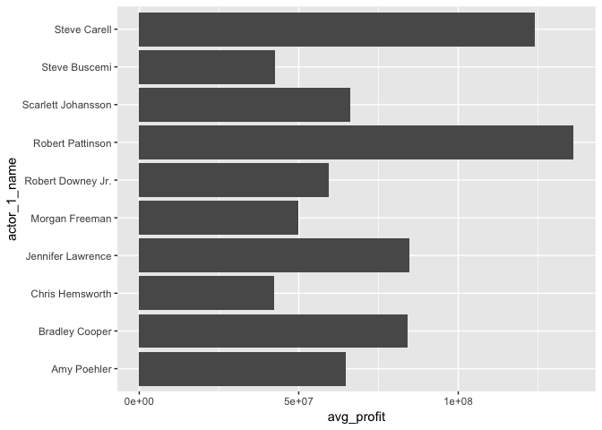

```r
Movie %>% group_by(actor_1_name) %>%
  summarise(avg_likes = mean(actor_1_facebook_likes, na.rm = TRUE)) %>%
  arrange(desc(avg_likes)) %>%
  slice(1:10) %>% subset(select = c(actor_1_name, avg_likes))

# Classification of profit based on actor_1 for movies after 2006 and having 5 or more movies

Movie %>%
  filter(title_year > 2006) %>% group_by(actor_1_name) %>%
  summarise(count = n(), avg_profit = mean(profit, na.rm = TRUE)) %>%
  filter(count>5) %>%
  arrange(-avg_profit) %>%
  slice(1:10) %>%
  ggplot(aes(x = actor_1_name, y = avg_profit)) + geom_bar(stat="identity")+coord_flip()
```

[output not shown]

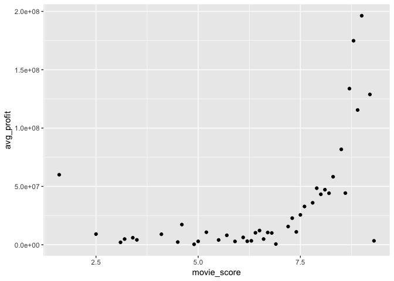

```r
# Profitability and movie score

Movie %>%  group_by(movie_score) %>%
  summarise(avg_profit = mean(profit, na.rm = TRUE)) %>%
  filter(avg_profit > 0) %>%
  ggplot(aes(x = movie_score, y = avg_profit))+geom_point()
```

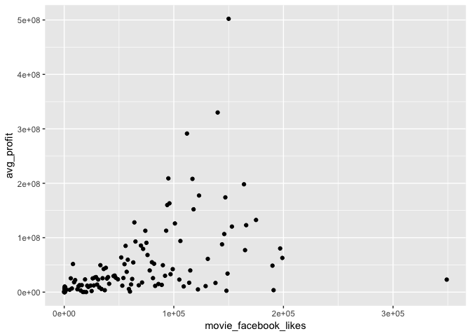

```r
# Profitability and movie_facebook_likes
Movie %>%  filter(title_year > 2006) %>% group_by(movie_facebook_likes) %>%
  summarise(avg_profit = mean(profit, na.rm = TRUE)) %>%
  filter(avg_profit > 0) %>%
  ggplot(aes(x = movie_facebook_likes, y = avg_profit))+geom_point()
```

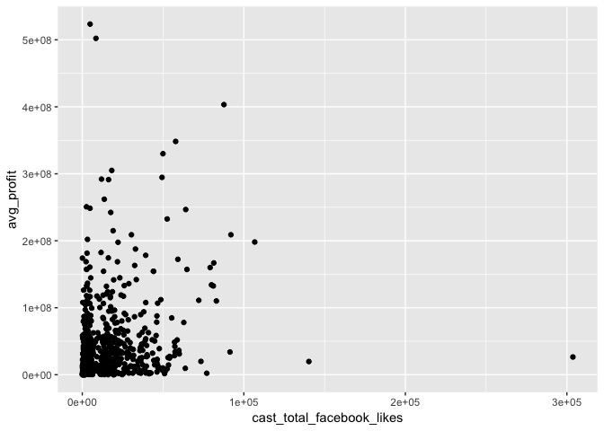

```r
# Profitability and cast_total_facebook_likes

Movie %>%  filter(title_year > 2006) %>% group_by(cast_total_facebook_likes) %>%
  summarise(avg_profit = mean(profit, na.rm = TRUE)) %>%
  filter(avg_profit > 0) %>%
  ggplot(aes(x = cast_total_facebook_likes, y = avg_profit))+geom_point()
```